# Inmobiliaria

Cargamos las paquterías que vamos a utilizar:

```python
import pandas as pd
import numpy as np
import matplotlib.pyplot as plt
import seaborn as sns
from pandas.plotting import scatter_matrix
from sklearn.model_selection import train_test_split
from sklearn.preprocessing import StandardScaler
from sklearn.impute import SimpleImputer
from sklearn.linear_model import LinearRegression, Ridge, Lasso
from sklearn.metrics import mean_absolute_error, mean_squared_error, r2_score
from statsmodels.formula.api import ols
```

```python
#!pip install openpyxl
#esta sólo se usa si no se ha instalado para leer archivos excel
```

Se carga el documento, el equipo decidió usar el archivo "10_percent_Florida", de la opción de precios de propiedades residenciales de la carpeta Zillow

```python
datos = pd.read_excel('Datos/10_percent_Florida.xlsx')
datos.head(10)
```

|  | listingDataSource | zpid | city | state | homeStatus | isListingClaimedByCurrentSignedInUser | isCurrentSignedInAgentResponsible | bedrooms | bathrooms | price | ... | image_urls | source_file | ADULTCOM | ADULTCOMFound_In_Columns | ANNUALDUES | ANNUALDUESFound_In_Columns | WAITINGPERIOD | WAITINGPERIODFound_In_Columns | BUYINFEE | BUYINFEEFound_In_Columns |
| --- | --- | --- | --- | --- | --- | --- | --- | --- | --- | --- | --- | --- | --- | --- | --- | --- | --- | --- | --- | --- | --- |
| 0 | Phoenix | 42977593 | tamarac | FL | for_sale | False | False | 3.0 | 2.0 | 435000 | ... | ["https://www.greatschools.org/florida/sunrise... | BROWARD_detailsVENTA120924_TODO_processed.xlsx | 0 | NaN | 0 | NaN | 0 | NaN | 0 | NaN |
| 1 | Phoenix | 43151113 | fort_lauderdale | FL | for_sale | False | False | 3.0 | 3.0 | 1199000 | ... | ["https://www.greatschools.org/florida/cooper-... | BROWARD_detailsVENTA120924_TODO_processed.xlsx | 0 | NaN | 0 | NaN | 0 | NaN | 0 | NaN |
| 2 | Phoenix | 155833951 | miami_beach | FL | for_sale | False | False | 3.0 | 4.0 | 5595000 | ... | ["https://www.greatschools.org/florida/miami-b... | MIAMI DADE_detailsVENTA120924_TODO_processed.xlsx | 0 | NaN | 0 | NaN | 0 | NaN | 0 | NaN |
| 3 | Phoenix | 44301933 | miami | FL | for_sale | False | False | 3.0 | 1.0 | 460000 | ... | ["https://www.greatschools.org/florida/palmett... | MIAMI DADE_detailsVENTA120924_TODO_processed.xlsx | 0 | NaN | 0 | NaN | 0 | NaN | 0 | NaN |
| 4 | Phoenix | 103464576 | west_palm_beach | FL | for_sale | False | False | 6.0 | 3.0 | 650000 | ... | ["https://www.greatschools.org/florida/west-pa... | PALM BEACH_detailsVENTA120924_TODO_processed.xlsx | 0 | NaN | 0 | NaN | 0 | NaN | 0 | NaN |
| 5 | Phoenix | 42907000 | pompano_beach | FL | for_sale | False | False | 3.0 | 1.0 | 389000 | ... | ["https://www.greatschools.org/florida/pompano... | BROWARD_detailsVENTA120924_TODO_processed.xlsx | 0 | NaN | 0 | NaN | 0 | NaN | 0 | NaN |
| 6 | Phoenix | 46765794 | delray_beach | FL | for_sale | False | False | 4.0 | 5.0 | 2999000 | ... | ["https://www.greatschools.org/florida/delray-... | PALM BEACH_detailsVENTA120924_TODO_processed.xlsx | 0 | NaN | 0 | NaN | 0 | NaN | 0 | NaN |
| 7 | Phoenix | 43881508 | miami_beach | FL | for_sale | False | False | 2.0 | 2.0 | 499000 | ... | ["https://www.greatschools.org/florida/miami-b... | MIAMI DADE_detailsVENTA120924_TODO_processed.xlsx | 0 | NaN | 0 | NaN | 0 | NaN | 0 | NaN |
| 8 | Phoenix | 337200955 | miami | FL | for_sale | False | False | 1.0 | 2.0 | 719000 | ... | ["https://www.greatschools.org/florida/miami/6... | MIAMI DADE_detailsVENTA120924_TODO_processed.xlsx | 0 | NaN | 0 | NaN | 0 | NaN | 0 | NaN |
| 9 | Phoenix | 71734790 | fort_lauderdale | FL | for_sale | False | False | 2.0 | 2.0 | 510000 | ... | ["https://www.greatschools.org/florida/fort-la... | BROWARD_detailsVENTA120924_TODO_processed.xlsx | 0 | NaN | 0 | NaN | 0 | NaN | 0 | NaN |

10 rows × 805 columns

Limpieza de datos

```python
#con .info () vemos todos los valores nulos dentro de nuestra tabla
datos.info()
#.describe sirve para mostrar un resumen de un estadístico descriptivo de los datos contenidos en datos.
print(datos.describe())
```

```
<class 'pandas.core.frame.DataFrame'>
RangeIndex: 2806 entries, 0 to 2805
Columns: 805 entries, listingDataSource to BUYINFEEFound_In_Columns
dtypes: bool(109), float64(311), int64(13), object(372)
memory usage: 15.2+ MB
               zpid     bedrooms    bathrooms         price   yearBuilt  \
count  2.806000e+03  2714.000000  2720.000000  2.806000e+03  2725.00000
mean   2.197555e+08     3.079587     2.799816  1.726639e+06  1985.11156
std    5.058730e+08     1.484508     1.541059  4.355494e+06    22.50474
min    4.282073e+07     0.000000     0.000000  0.000000e+00  1889.00000
25%    4.386455e+07     2.000000     2.000000  3.850000e+05  1970.00000
50%    4.663425e+07     3.000000     2.000000  6.500000e+05  1984.00000
75%    7.173174e+07     4.000000     3.000000  1.270000e+06  2003.00000
max    2.141801e+09    30.000000    18.000000  8.890000e+07  2027.00000

            zipcode  propertyUpdatePageLink  moveHomeMapLocationLink  \
count   2806.000000                     0.0                      0.0
mean   33261.277263                     NaN                      NaN
std      183.598621                     NaN                      NaN
min    33001.000000                     NaN                      NaN
25%    33129.000000                     NaN                      NaN
50%    33301.000000                     NaN                      NaN
75%    33426.000000                     NaN                      NaN
max    34145.000000                     NaN                      NaN

       propertyEventLogLink  editPropertyHistorylink  ...  \
count                   0.0                      0.0  ...
mean                    NaN                      NaN  ...
std                     NaN                      NaN  ...
min                     NaN                      NaN  ...
25%                     NaN                      NaN  ...
50%                     NaN                      NaN  ...
75%                     NaN                      NaN  ...
max                     NaN                      NaN  ...

       price_to_rent_ratio_InfoTOD  \
count                  1754.000000
mean                    183.923629
std                     205.839690
min                       9.090909
```

[output cut: 31 more lines]

```
50%                                   NaN     0.000000     0.000000
75%                                   NaN     0.000000     0.000000
max                                   NaN     1.000000     1.000000

       WAITINGPERIOD  BUYINFEE  BUYINFEEFound_In_Columns
count    2806.000000    2806.0                       0.0
mean        0.002851       0.0                       NaN
std         0.053328       0.0                       NaN
min         0.000000       0.0                       NaN
25%         0.000000       0.0                       NaN
50%         0.000000       0.0                       NaN
75%         0.000000       0.0                       NaN
max         1.000000       0.0                       NaN

[8 rows x 324 columns]
```

```python
#nos muestra las columnas
datos.columns
```

```
Index(['listingDataSource', 'zpid', 'city', 'state', 'homeStatus',
       'isListingClaimedByCurrentSignedInUser',
       'isCurrentSignedInAgentResponsible', 'bedrooms', 'bathrooms', 'price',
       ...
       'image_urls', 'source_file', 'ADULTCOM', 'ADULTCOMFound_In_Columns',
       'ANNUALDUES', 'ANNUALDUESFound_In_Columns', 'WAITINGPERIOD',
       'WAITINGPERIODFound_In_Columns', 'BUYINFEE',
       'BUYINFEEFound_In_Columns'],
      dtype='object', length=805)
```

Con estos visuales podemos ver los datos a analizar

Ahora haremos un histograma, sólo contemplaremos los datos que nos parezcan relevantes de la tabla

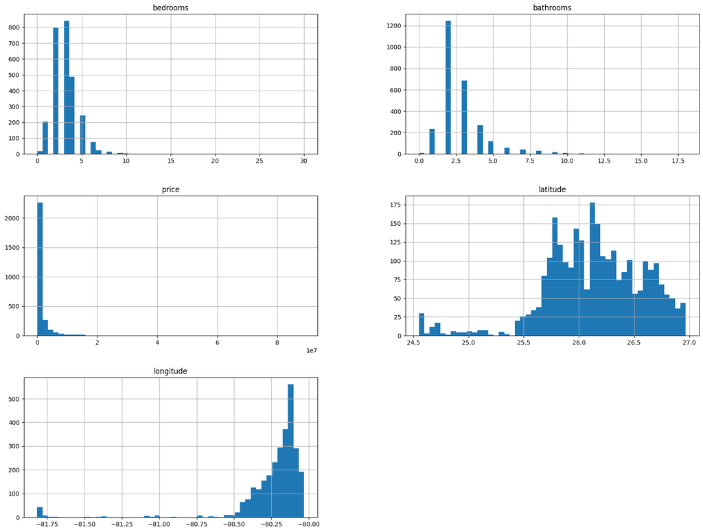

```python
datos[['bedrooms', 'bathrooms', 'price', 'latitude', 'longitude']].hist(bins = 50, figsize = (20, 15))
plt.show()
```

Las variables que no se vieron representadas en los gráficos fueron: 'city', 'state', 'homeStatus', esto es debido a que son textos para ello debemos trasformarlas con ayuda de las dummies con ayuda del comando pd.get_dummies.

## Filtro

Hacemos un filtro de los datos basándonos en el histograma anterior, en este vamos a contemplar los inmuebles que esten arriba de 1000 dólares, pero por debajo de 20000000 de dólares, no contemplaremos datos más grandes a estos puesto que son pocos y causan ruido inecesario en el modelo

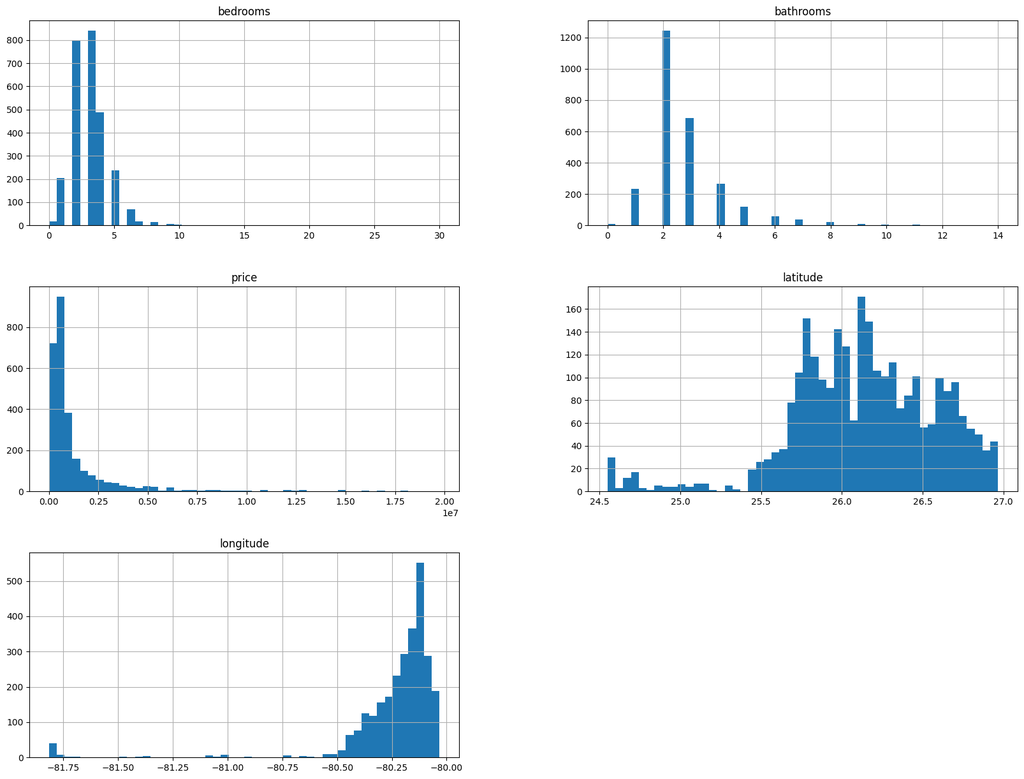

```python
datos_1 = datos[(datos['price'] > 1000) & (datos['price'] < 20000000)]
datos_1[['bedrooms','bathrooms', 'price', 'latitude', 'longitude']].hist(bins = 50, figsize = (20, 15))
plt.show()
```

En este histograma haremos un filtro de las recamaras escogeremos que sea mayor a 0 y menor a 10, no contemplaremos datos más grandes a estos puesto que son pocos y causan ruido inecesario en el modelo

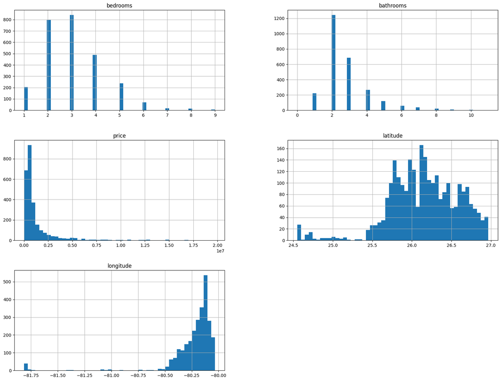

```python
datos_1 = datos_1[(datos_1['bedrooms'] > 0) & (datos_1['bedrooms'] < 10)]
datos_1[['bedrooms','bathrooms', 'price', 'latitude', 'longitude']].hist(bins = 50, figsize = (20, 15))
plt.show()
```

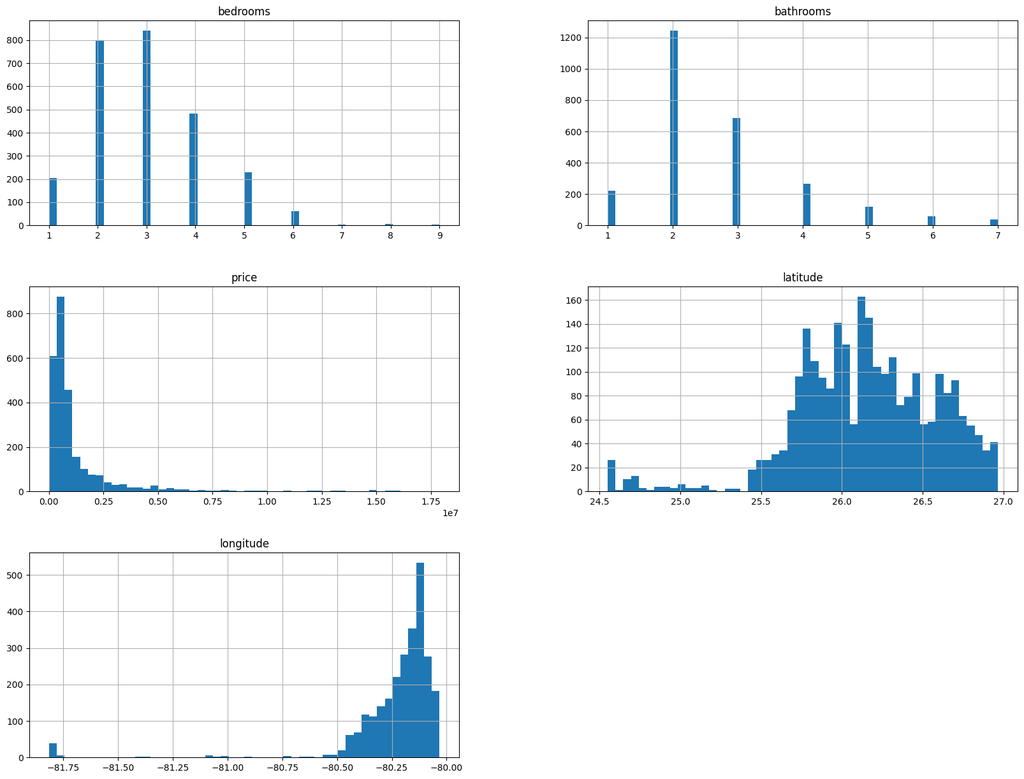

```python
datos_1 = datos_1[(datos_1['bathrooms'] > 0) & (datos_1['bathrooms'] < 8)]
datos_1[['bedrooms','bathrooms', 'price', 'latitude', 'longitude']].hist(bins = 50, figsize = (20, 15))
plt.show()
```

Meteremos un filtro para latitud y longitud tomando en cuenta la concentración de los datos

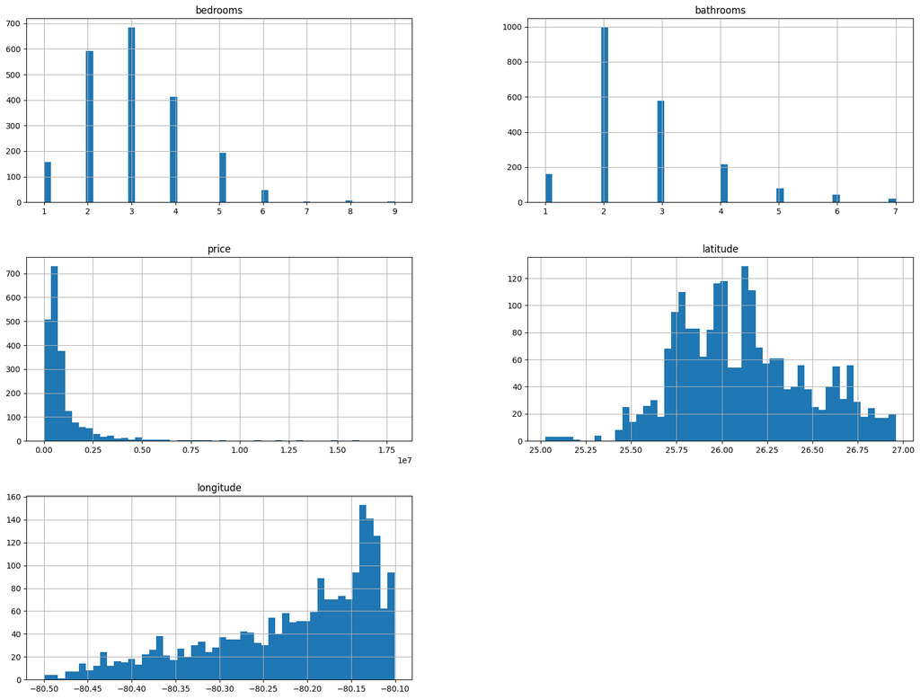

```python
datos_1 = datos_1[
    (datos_1['latitude'] > 24.800000) & (datos_1['latitude'] < 26.967148) &
    (datos_1['longitude'] > -80.500000) & (datos_1['longitude'] < -80.100655)
]
datos_1[['bedrooms','bathrooms', 'price', 'latitude', 'longitude']].hist(bins=50, figsize=(20, 15))
plt.show()
```

En suma

```python
datos_1 = datos[
    (datos['price'] > 1000) & (datos['price'] < 20000000) &
    (datos['bedrooms'] > 0) & (datos['bedrooms'] < 10) &
    (datos['bathrooms'] > 0) & (datos['bathrooms'] < 8) &
    (datos['latitude'] > 24.800000) & (datos['latitude'] < 26.967148) &
    (datos['longitude'] > -80.500000) & (datos['longitude'] < -80.100655)
]
```